# Architectural Forms and Settlement Patterns

Green, R. and Pawley, A.

## 1. Aims and methodological preliminaries

This chapter seeks to reconstruct something of the architectural elements and settlement patterns of speakers of Proto Oceanic and its immediate descendants, speech communities that many associate with the colonisation of south-west Oceania by bearers of the archaeological culture known as Lapita in the second half of the 2nd millennium BC (Bellwood 1978, Pawley & Ross 1995, Shutler & Marck 1975, Spriggs 1995).[^1]

Some methodological questions are in order. Are such culture historical reconstructions feasible? Which disciplines and methods can provide evidence relevant to this task? What is each method good for, and to what extent, if at all, can evidence provided by different methods be connected?

At least three distinct disciplines—historical linguistics, archaeology and comparative ethnology—are used to do culture history. Each discipline has particular strengths and limitations.[^2] Although their combined testimonies are likely to reveal a fuller picture than any yielded by a single discipline, synthesising evidence from diverse disciplines and methods is not a straightforward matter. A synthesiser can accept the testimony of different disciplines but it is not easy to know when the witnesses are talking about the same historical events. One is reminded of the story of the six blind philosophers each of whom touched a different part of an elephant and then equated the parts with six unrelated objects.

The richest primary data for culture historical reconstruction come from comparative ethnology (or comparative ethnography, if you prefer). This discipline has the advantage, under favourable circumstances, of starting with descriptions of contemporary or historical societies and cultures that are immensely more complete than anything the archaeologist can hope to recover. However, the historical method of comparative ethnology is a fairly blunt instrument.[^3] The method is based on general arguments from typology. From contemporary reports of cultures the comparative ethnologist may arrive at a theory of earlier cultural types and their transformations or their directions of diffusion. The proofs for drawing such inferences are essentially statistical, based on the frequency and distribution of types and typological associations in contemporary societies: often the most common and/or most widely distributed type is assumed to be the oldest. A problem familiar to archaeologists and linguists who use ethnographic analogy is that the reconstructed past becomes simply an extension and reflection of one’s knowledge of present-day traditional societies. Quite different pasts are not easily recognised.

The following remarks by Waterson (1993: 221) about the antiquity of houses on piles and roof styles are fairly typical of the kinds of argumentation used by historical ethnologists:

> Architectural styles can change rapidly—but they can also maintain continuity over surprisingly long periods. The antiquity of some aspects of architectural style in the Austronesian world is undoubted. Elements such as pile building and the saddle roof with its extended ridge line are first to be seen on the bronze drums of the Dong Son era, but to judge from their appearance in regions as distant from the [Southeast Asian] mainland as Micronesia and New Guinea, it is reasonable to assume they are much older than their earliest surviving pictorial representations; in other words, that this style is a genuinely Austronesian invention.

In her two-volume work, *Kulthäuser in Nordneuguinea*, Hauser-Schäublin (1989: 618) writes as follows of houses in a region that contains hundreds of non-Austronesian languages as well as a smaller number of Austronesian languages:

> The hut on piles with supports carrying both the roof and the built-in floor seems to belong to Austronesian cultures. On the North Coast both elements are combined: the first floor platform is supported by its own poles, whereas the upper floors are slotted into the horizontal beams. In areas settled by non-Austronesian groups, all parts of the building are traditionally lashed with lianas. Pin and peg techniques are only known in those regions where Austronesian languages are spoken. The Middle Sepik cultures took over the idea of buildings with projecting gables from the Austronesians who settled at certain places on the North Coast. They adapted it to their own technology and architectural experience, giving it a new expression. [translated from the German, in Waterson 1993]

Note the temporal priorities assigned in these two accounts. The conclusions about what is older and younger based on ethnological distributions may well be valid, but how much confidence can we place in them? The same reservations apply to conclusions about directions of diffusion. A serious weakness of comparative ethnology, as an instrument for doing prehistory, is that it has no very reliable way of distinguishing between shared resemblances among a set of contemporary cultures that are due to (a) retention from a common ancestral tradition, (b) convergent development, or (c) diffusion.

In a different context, Bellwood has remarked that “only archaeology will tell us for certain whether pile-built dwellings really belong to an early phase of Western Austronesian culture, or whether they have been diffused at a much later date…” (Bellwood 1987:92). As we shall see, in that particular matter, historical linguistics can also provide crucial evidence.

Granted these caveats, the evidence of comparative ethnology can at times be very suggestive. Thus it forms one of the more fruitful sources of testable interpretations about the recent past and of analogical inferences employed by archaeologists in their reconstructions. Such evidence can provide a useful constraint on the semantic reconstructions proposed by linguists. For example, in his study of Austronesian terms for ‘house’, Blust (1987) gave good reasons for glossing POc *kamali(R) as ‘men’s house’. He then proposed to extend this gloss back to Proto Malaya-Polynesian (PMP). However, Fox (1993) and Waterson (1993) give ethnographic arguments for rejecting this last proposal. A building specifically for men alone to use as a meeting and sleeping place and for ritual activities is common among Austronesian societies only in parts of Melanesia. Fox (1993: 12) suggests, reasonably, that the institution of a men’s house was not part of original Austronesian or Malayo-Polynesian culture, but was borrowed by early Oceanic speakers from non-Austronesian speaking peoples of Melanesia.

The great advantage of prehistoric archaeology over comparative ethnology and historical linguistics is that it can locate particular assemblages of structural and portable artefacts more precisely in space and time. However, archaeologists must generally make do with extremely fragmentary data. The portable artefacts recovered are typically confined to durable items of material culture while those of the structural kind require extensive excavations of the remnants of structures and the below-ground imprints of features. Often only a very small sample of the range of a society’s entire material culture is recovered and inferences about the rest of the culture—including its systems of behaviour and belief—must be made on indirect grounds.

The strengths and weaknesses of historical linguistics are largely complementary to those of archaeology and comparative ethnology. Like ethnologists, linguists draw their primary data from reports of contemporary or historical language-culture systems. They lack truly reliable methods for placing in space or absolute time the languages and linguistic events they reconstruct. Unlike comparative ethnology, however, historical linguistics has a method for reconstructing prehistoric events that is quite distinct from typology. (Strictly speaking, it has a theory, which underlies a set of established procedures for interpreting data, including techniques for evaluating competing interpretations.) This method or theory derives its force from the fact that in all languages the code for forming minimal signs (morphemes) is arbitrary, i.e. the conventions for pairing form (pronunciation) and meaning in morphemes are not based on functional considerations. For this reason, unrelated languages are unlikely to show anything more than occasional resemblances in their morphemes, unless there has been borrowing between them. Languages, like organisms, are highly integrated systems and certain elements in the system—particular sounds and particular morphemes—show a continuity over time that may usefully be called ‘genetic’. These continuities are traceable in spite of changes in the form of these elements across generations of speakers.

The special nature of linguistic systems and linguistic change gives linguists a powerful method for reconstructing the histories of related words (cognates) shared by sister languages. In any language the sounds and meanings of the words of a language undergo constant, though normally gradual, change. In time, over many thousands of years, all languages will change beyond recognition if they continue to be spoken at all. Paradoxically, it is precisely this fragility of linguistic artefacts, together with the regular nature of one kind of linguistic change, which makes it possible (i) to distinguish genetic relationship from other kinds of resemblances and (ii) to determine subgrouping or family tree relationships within genetic stocks. Regular change is characteristic of sound systems. In a socially homogeneous speech community, pronunciations tend to change regularly, such that if in some words the sound x changes to y under certain structural conditions, say [t] to [s] before [i], or [p] to [v] between vowels, that change will generally extend to all words that meet those structural conditions. However, words borrowed from a sister language or dialect after the change x to y is complete usually will not undergo that change and, in that case, will be detectable as anomalous.

The weakest link in linguistic reconstructions is meaning. Semantic change is not regular or systematic in the way that sound change is, and when cognates in languages A, B, C, etc. exhibit a diverse range of meanings, it may be difficult to determine the original meaning(s). Some of the procedures linguists adopt to constrain semantic reconstruction are discussed in Blust (1987). How linguists approach these issues and the problems they pose for archaeologists who wish to use such reconstructions is discussed in Green (1994a).

The linguistic comparative method works well only at fairly shallow time depths because cumulative change wears away the evidence of common origin. There have been few cases in which the genetic comparative method has reliably penetrated much deeper than about 6,000 years. No special mystique should be attached to this particular figure—it happens that several of the large, well-defined language families in the world are the outcome of dispersals that began within the last 5,000 to 6,000 years.[^4] When the relevant cognate sets survive, the reconstructions for prehistoric ‘artefacts’ and ‘ecofacts’ accessible to historical linguistics cover an extremely wide range of cultural domains—so this discipline is well equipped to recover elements of the perishable material often unavailable to archaeologists as well as cognitive aspects of social organisation, beliefs, and ideology that archaeologists find difficult to infer. However, historical linguistics must look to archaeology to supplement its relatively weak methods for locating reconstructed prehistoric languages in space and in absolute time.

But here an old problem arises: How can reconstructed languages be correlated with archaeological assemblages? For instance, how can one make a strong claim about whether a particular Lapita site was occupied by Austronesian speakers or by non-Austronesian speakers? Aren’t there culture areas where people speaking different, indeed unrelated, languages share very similar material cultures? Welch et al. (1992) certainly make such a claim concerning the Sepik coast (and Lapita), but things have not turned out to be as clearcut as they supposed (cf. Moore & Romney 1994, 1995, Roberts, Moore & Romney 1995). The answer is that we can confidently make the Austronesian-Lapita association only when one or more of the following conditions are met: (a) when there is good evidence for believing that Austronesian speakers were the only people to inhabit a region in prehistoric times—as is the case in, say, Micronesia, Fiji and Polynesia—or at least around the time in question, as appears to be the case in, say, the area of Central Papua around Port Moresby 2,000 years ago; (b) when there is well-established continuity between the prehistoric site or sites in question and recent, historically documented Austronesian-speaking communities in the region; (c) in the case of regions known to have been inhabited by both Austronesian and non-Austronesian speakers, when the material culture of Austronesian speakers is sharply distinct from that of non-Austronesian speakers. And if a site was occupied by Austronesian speakers, we may ask how it can be shown that the occupants were speakers of, say, stage A or subgroup A of Austronesian rather than stage B or subgroup B. The short answer is that this is a complicated business that involves taking account of the distribution of subgroups, continuities and discontinuities in the archaeological sequence, and geographic, demographic and political factors.

Our strategy, since the mid-1960s, has been to seek detailed, systematic points of connection between particular prehistoric cultures and cultural sequences in the Pacific Islands, as defined by archaeology and historical linguistics, respectively, always with an eye on the comparative ethnology.[^5] The islands of the Polynesian Triangle, settled so late in human history, have been an ideal laboratory to make such correlations. In Melanesia, a region with a far more complex prehistory, but receiving far less attention, the pieces have not come together nearly so well. But over the past 30 years it has gradually become increasingly evident that the settlement of Near Oceania by Austronesian speakers preceded the first Austronesian settlement of Remote Oceania by only a few hundred years.

Between 1500 and 1000 BC variants of a culture known as Lapita appear in the archaeological record across a wide belt in the Southwest and Central Pacific (Allen & Gosden 1991, Galipaud 1992, Green 1967, 1979, 1994a, Kirch & Hunt 1988, Spriggs 1990, 1995, 1996; see Map 5). The chief markers of Lapita sites are well-made earthenware with a characteristic variety of vessel shapes, with some vessels decorated by very distinctive, elaborate dentate-stamped geometric motifs. Lapita pottery is usually associated with other features. Settlements are in the hamlet-to-village range and nearly always situated on small islands or on the coast of large islands and handy to beaches that would provide good launching sites for boats. The Lapita tool kit frequently contains ground and polished stone and shell adzes; obsidian and chert flake tools, often imported from remote sources; one-piece shell fishhooks; pearlshell knives and scrapers; various kinds of conus shell disks and pendants; earth ovens; and middens full of lagoon fish and turtle bones and also containing the bones of dog, chicken and pig.

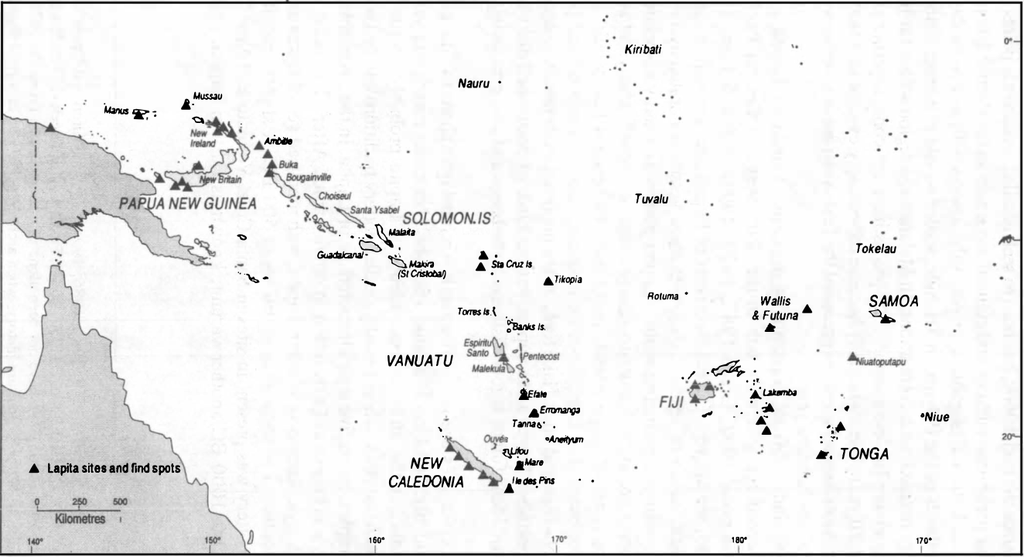

**Map 5:** Lapita sites in the south-west Pacific (after Spriggs_1995: 113)

On currently favoured subgrouping hypotheses, the likeliest dispersal centre for the Oceanic subgroup was the Bismarck Archipelago (Pawley & Ross 1993, 1995, Ross 1988; cf. also Grace 1961, 1964). This conclusion is consistent with the view that the break-up of Proto Oceanic (POc) was associated with the dispersal of the Lapita culture beyond the Bismarcks after about 1300 BC.

Throughout Remote Oceania the appearance of the Lapita culture can be associated with the first arrival in the region of Austronesian languages, specifically members of the Oceanic subgroup. The connections are easiest to make in Fiji and Western Polynesia, regions that almost certainly were not inhabited by humans before the bearers of the Lapita culture arrived. In Fiji and Polynesia there is a continuity of tradition, with more or less gradual change, from Eastern Lapita material culture to later archaeological cultures that are clearly ancestral to recent, historically documented cultures. Comparable continuities are harder to demonstrate in parts of Remote Oceania west of Fiji, where the archaeological record has become more complex, but a strong case can still be made there for the Lapita-Oceanic Austronesian association (Green 1997).

## 2. Settlement patterns: evidence from archaeology and comparative ethnology

The archaeological record tells us much about the siting and size of Lapita sites. All 36 sites of known size are on the coast (see Map 5), usually handy to lagoons and beaches that would have provided seafood and canoe landing and launching places. Settlements cover the typical Oceanic ethnographic range from hamlets to small villages, though a few are larger (the largest being 72,500 m²) (Green 1994b). But what does archaeology tell us of the internal organisation of Lapita settlements? Disappointingly little. Although the size of most Lapita living sites has been calculated from surface features, such as the distribution of potsherds, only a few sites have been extensively excavated. Thus, reconstructions of the internal organisation of Lapita settlements rest mainly on a few large-scale investigations of portions of settlement areas (e.g. Best 1984, Frimigacci 1974, 1980, Kirch 1988, Poulsen 1987, Sheppard & Green 1991).

The ethnological record on settlement patterns and architecture in Austronesian-speaking societies is far too extensive to review here. Our remarks must be very brief and selective. We will use selected ethnological evidence and a comparative approach mainly to generate hypotheses that might be tested against evidence from archaeology and/or linguistics.

For example, certain features of Austronesian settlements in Oceania were so widespread at first European contact, that one may reasonably ask whether these directly continued traditions established during the initial dispersal of Oceanic languages. Recurrent features noted in the literature (Forge 1972, Hogbin & Wedgwood 1953, Oliver 1989) include those set out below.

1. There is a preference for coastal settlements, handy to reef/lagoon systems and beaches with landing places for boats, and to garden land in the interior.
2. Both dispersed and nucleated settlements are common. Dispersed settlements, sometimes containing hamlets inhabited by a few extended families, are commonest where land is plentiful. Nucleated settlements, consisting of villages of up to 300 people, are invariably found when land is in short supply and, where attacks are feared, settlements may be situated in inaccessible places with defences constructed.
3. In villages where the terrain allows, main dwellings are generally arranged in parallel lines on each side of a rectangular space that serves as a ceremonial centre for the settlement.
4. Villages divide into sections or wards each belonging to a single lineage (or section of a lineage) and containing one or more households.
5. The sections are not physically bounded but each lineage owns certain house sites and these sites have considerable ritual importance.
6. Each family or extended family has a rectangular main house, which in western Melanesia is generally raised on piles; but in eastern Melanesia, nuclear Micronesia and Polynesia comes in both rectangular, oval, and round forms and is usually (there are some exceptions in Micronesia) built on the ground or, in some regions, on a flat mound.
7. Main dwelling houses have two-section thatched roofs with high gable. This relatively heavy superstructure is supported by large posts and beams.
8. There is a porch in the front of raised houses and often on those built on the ground.
9. The interior of the main dwelling is divided into compartments with an inner room or compartment for sleeping and an outer ‘living room’.
10. While main houses serve as sleeping places and as storage places for valuables, much daily life takes place in smaller, less durable structures erected on the ground near the main dwelling and used for various daytime activities such as preparing food, cooking, eating, weaving mats, conversation with neighbours and sometimes for sleeping in at night. These structures, including kitchen and day-houses, are less well built, being open-sided or only partly walled, often with flat roofs of coconut leaves or rough thatching.
11. Coastal settlements have open-sided boat houses, each usually belonging to an extended family.
12. In yam-growing areas there are storage houses with raised platforms for keeping yams; similar structures often occur elsewhere.
13. In parts of Melanesia a men’s house is commonly part of the hamlet or village, providing a centre where men and boys may congregate and perform certain rituals from which women are barred.
14. A menstrual hut is sometimes built near the main dwelling of a family.
15. Ovens made with heated stones, including both earth ovens (where the food is cooked in pits) and above-ground ovens, occur close to the dwellings.
16. Graves, often marked by piles of stones, may be sited under or close to the main dwelling house.
17. The ritual activity of kin groups is focused in dwelling houses. The principal ritual foci within the house are the posts, entrance, ridge-pole and hearth.

In a passage cited earlier, Hauser-Schäublin (1989) discussed features of house design among Austronesian peoples of the central north coast of New Guinea. Let us take another example, from south-eastern New Guinea. The traditional dwelling houses of the people of Goodenough Island in the D’Entrecasteaux group were, by Austronesian standards, extremely modest structures, smaller and less elaborately constructed than the grander houses of many regions. Yet they exhibit most of the basic structural features of dwelling houses among the coastal Austronesian-speaking peoples living throughout the New Guinea area. The following description (cited in Young 1993: 182) applies to the early contact period of 1911-12.

> All houses … are erected on four poles forked at the top to hold the plates … Two plates run horizontally from the front to the back posts of the house, and from them a series of poles and rafters lead up and support the ridge pole. Everything is firmly lashed together with vines … Thus the framework of the house is provided; for walls it is covered with overlapping layers of sago-leaf matting. Back and front are sometimes covered in the same way, but often the matting is here replaced by planks on which the native can display his artistic powers. The back wall is unbroken but a gap is left in the front by which the inmates can enter; it can be closed at will by native mats. A platform is often built in front, usually as a mere extension of the floor, though sometimes a foot or so lower. This … offers a very convenient place to sit and gossip, especially when the roof and sides are made to project as well and so ward off both sun and rain. Propped up against the platform … will be found a ladder, which is simply the stem of a small tree with notches cut for steps at intervals of a few inches. The floor is made of transverse poles or rough boards resting on the plates, and is generally covered with mats of coconut leaves. The interior is sometimes divided into an inner and an outer compartment, with a gap in the dividing wall similar to that in the front of the house. In some houses there is a low bench running along one side, for the inmates to sleep on, but this is not very common.

> … A medium sized hut that we measured had a front of 22’6” (6.9 m) and a depth of 26’ (8 m). The platform, which extended 6’ (1.8 m) outwards from the floor, was 5’ (1.5 m) above the ground, and the height of the room inside from floor to ridge-pole was only 4’8” (1.4 m) (Jenness & Ballantyne 1920: 182-183).

In his overview of domicile arrangements in Island Melanesia, Oliver (1989: 333) chose a community of the Austronesian-speaking Baegu (Malaita, Solomon Islands) to “typify, substantively, hundreds of Island Melanesia’s thousands of communities” (New Guinea communities are given separate treatment). Given his extensive ethnographic knowledge of the region, and his objective in setting up a model to characterise most communities in it, the selection of Baegu is, one would believe, no accident. And it suits well the need for a general ethnographic guideline within which to work.

Baegu communities consist of one or more *fera* (or hamlets) (Ross 1973). Although *fera* “had no visible boundaries and little symbolic identity, they remained more or less localised and were distinctly perceptible in terms of social interactions of the members”. Baegu local communities become more ‘solidary’ under the influence of ‘focal’ men, clan seniors and priests whose statuses were ascribed by birth, and feast givers and war leaders whose positions were achieved.

Note also the gender arrangements and symbolic structures of relations within and without the *fera*, shown in Figure 2. Strikingly similar parallelism of inside-outside structural relations, physical and symbolic, were noted by Goodenough (1983) for Malekula and the Polynesian *marae* and by Green (1986: 54) for a Kwaio settlement in relation to Polynesian settlements.

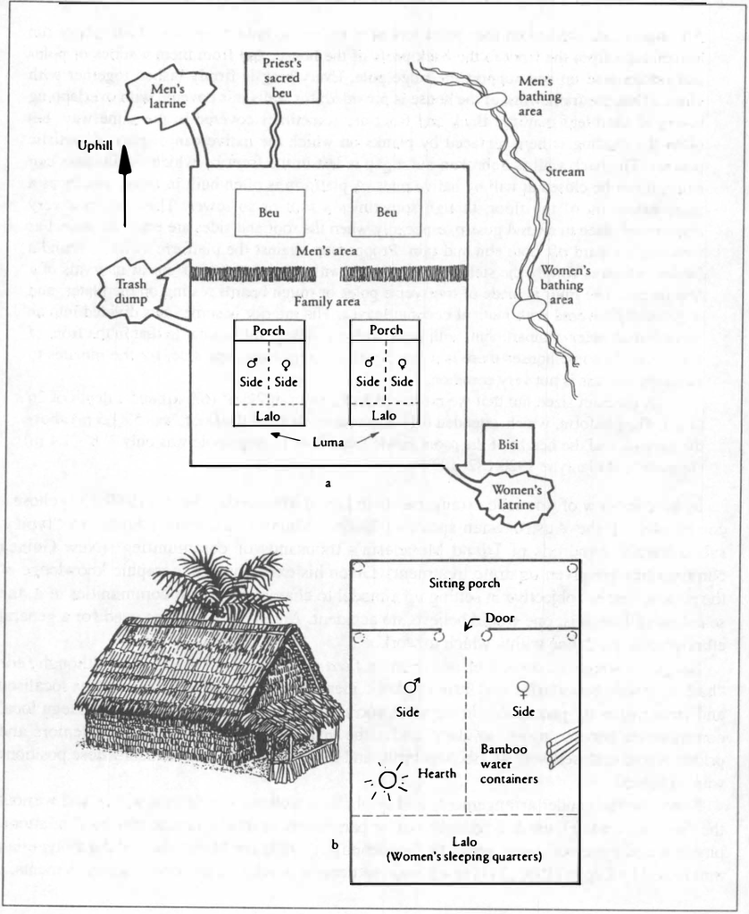

**Figure 2:** Typical Baegu (Malaita, Solomon Islands) dwelling and community layout (from Oliver_1989:335) (Baegu terms are *luma* ‘dwelling house, *lalo* ’women’s sleeping quarters’, *beu* ‘men’s house’, *bisi* ‘menstrual hut’)

### 2.1. Dwelling house architecture

Most Oceanic-speaking societies distinguish by name more than one design of dwelling house. Arosi speakers, of San Cristobal in the Solomons, for instance, first distinguish *ruma* ‘a house, oblong in shape’ from *hare* ‘a shed for yams, a house with roof thatched on one side only, a shrine (a small house on poles)’ and then distinguish at least the following kinds of *ruma* (Fox 1978):

- *ruma huri*, a round house, taller than the well-known Santa Cruz round house
- *ruma gaura*, a double, oblong house
- *ruma ora*, a house with ten posts or more (five pairs of posts)
- *ruma pʷarapʷara*, a house roughly built, with roof of whole fronds instead of thatching
- *ruma rangi*, a house with two roofs, the second roof only above the upper part of the first roof, made by extending the rafters upwards
- *ruma rokera*, like ruma rangi but the two roofs close together
- *ruma sinakuhi*, house with rounded end
- *ruma waiho*, simplest form of oblong house with six posts (three pairs).

Are there significant structural differences between the houses and settlements of Austronesian and non-Austronesian speakers in Melanesia? It is hazardous to generalise—in these matters individual societies in Melanesia show considerable variation and in certain regions there has been much cultural influence across linguistic boundaries. But if we exclude the most problematic cases, the following generalisations about non-Austronesian societies seem to apply rather widely.

1. There is a preference for inland settlements.
2. Main dwelling houses are built on the ground, not on piles.
3. Houses are relatively small and lack a high, gabled roof requiring strong crossbeams and centre-posts. Instead, the roof is relatively low and flat or domed with the support of centre poles.
4. Timbers are lashed, and seldom secured by wooden pins or pegs.
5. There is no projecting gable.
6. There is no porch or raised open platform outside the room.
7. There is often a men’s house.
8. Boat houses are absent.
9. Stone heated ovens, including earth ovens, are made close to the dwellings.

The ethnological evidence suggests various questions for culture history. Can we show by linguistic or archaeological evidence that these features were part of the settlement patterns of Proto Oceanic speakers and their immediate descendants?

## 3. Settlement patterns: evidence from comparative linguistics

### 3.1. Subgrouping

Given the minimal subgrouping assumptions set out in the Introduction, we can reconstruct a Proto Oceanic etymon for any set of cognate lexical units that is regularly reflected in at least one language in any two of the following subgroups or sets: (a) the Admiralties, (b) Western Oceanic, (c) Eastern Oceanic, or in at least one Oceanic language and one non-Oceanic Austronesian language.

Interstages later than Proto Oceanic are also of interest. Of particular concern are those that might be associated with archaeologically discernible events, such as the first appearance of the Lapita culture in certain regions or changes in architectural or settlement patterns. Lapita appears in the Bismarck Archipelago between 1500 and 1300 BC and spread rapidly south-east across the SW Pacific as far as Fiji and Western Polynesia. If the bearers of Lapita spoke hardly differentiated dialects of Oceanic when they spread to the major archipelagos of SW Melanesia, it should occasion no surprise that it is hard to find evidence for subgroups that span different archipelagos in that region. What we do find is a number of fairly well-defined subgroups confined to particular island groups of Remote Oceania.

There are two prominent exceptions to this prevalence of geographically compact major subgroups. Each of the Polynesian and Nuclear Micronesian groups is spread over a number of far-flung archipelagos. The many innovations defining the Polynesian subgroup indicate a long pause, probably on the order of 1,000 years, in a compact area before dispersal (Clark 1979, Pawley 1996a). From the internal subgrouping of Polynesian one can deduce that this ‘homeland’ was in the Tonga-Samoa area (Green 1966, 1981). Evidence for a period of common development uniting the Polynesian subgroup with the Fijian languages and Rotuman (Geraghty 1983, 1986, Pawley 1996a) is consistent with this view, as is the archaeological evidence for the Fiji-West Polynesia region (Green 1981, Kirch & Green 1987). The internal structure of the Nuclear Micronesian subgroup, as defined by Bender (1971) and Jackson (1983), suggests an initial dispersal centre somewhere in the eastern half of Micronesia.

### 3.2. Lexical reconstructions

A number of cognate sets yield lexical reconstructions that tell something about early Austronesian settlement patterns. These are treated here under the headings: (a) kinds of buildings, (b) house site and main structural components of house, (c) other structures associated with buildings or settlements and (d) spatial organisation of settlements. We will focus on those etyma that are definitely or possibly attributable to Proto Oceanic, noting in passing others that have considerable antiquity but cannot be reconstructed for Proto Oceanic.

### 3.3. Kinds of buildings

Blust (1987) compared four widely distributed cognate sets whose members generally name types of domestic buildings. He attributed the reconstruction *Rumaq ‘dwelling house’ to both PAn and PMP but could reconstruct the terms *balay, *kamaliR and *lepaw only as far back as PMP, tentatively attributing to them the respective senses of ‘public building’, ‘men’s house’ and ‘granary’. His formal reconstructions are secure but the semantic reconstructions for the last three forms are somewhat problematic. *lepaw is not known to have Oceanic reflexes. The other three terms are all reflected in a number of Oceanic subgroups and therefore must be attributed to POc. Let us briefly review the lexical reconstructions and supporting data.

| **PAn** |  | *Rumaq | ‘dwelling house’ (Blust 1987) |
| --- | --- | --- | --- |
| **POc** |  | *Rumaq | ‘house’ |
| Adm | Lou | *um* |  |
| NNG | Arawe | *a-rumuk* | ‘village’ |
| NNG | Vehes | *ɣumak* |  |
| PT | Motu | *ruma* |  |
| MM | Bali | *rumaka* |  |
| MM | Petats | *luma* |  |
| SES | Lau | *luma* | ‘family house’ |
| SES | Arosi | *ruma* |  |
| NCV | Mota | *ima* |  |
| NCV | Tasiriki | *ima* |  |
| NCV | Lewo | *yuma* |  |
| SV | Lenakel | *n-imʷa* |  |
| NCal | Dehu | *uma* |  |
| Mic | Ponapean | *īmʷ* | ‘building, house, home, dwelling’ |
| Mic | Kiribatese | *uma* | ‘any kind of dwelling’ |

The central sense of PAn, PMP and POc *Rumaq is uncontroversial: in contemporary Austronesian languages this form is widely reflected in the meaning ‘house, dwelling’, including the main dwelling house of a family or larger kin-group. In Oceania, reflexes having this meaning are found in all major groups except Central Pacific. The question remains whether *Rumaq had other, secondary senses. Fox (1993) notes that “among Austronesian populations [reflexes of *Rumaq are] often given a metaphoric sense to define an associated social group claiming some kind of common derivation or ritual unity …”. Blust (1980a) reconstructed PMP *Rumaq ‘lineage, descent group’. This and associated reconstructions sparked off a lively discussion about early Austronesian social organisation which need not concern us here but could prove important in the interpretation of Lapita society. Suffice to say the present day evidence for such a figurative use of *Rumaq appears to be centred in Indonesia and lacking in Oceania.

| **PMP** |  | *balay | ‘open-sided building’ |
| --- | --- | --- | --- |
| **POc** |  | *pale | ‘open-sided building’ |
| Adm | Mussau | *ale* | ‘house’ |
| Adm | Lou | *pal* | ‘canoe hut’ |
| NNG | Bebeli | *bele* | ‘house’ |
| NNG | Yabem | *ale* | ‘house’ |
| NNG | Lukep (Pono) | *para* | ‘yam house’ |
| MM | Tolai | *pal* | ‘house’ |
| MM | Tangga | *pal* | ‘small house or shed, canoe shed, storehouse for gifts of food’ |
| MM | Mono-Alu | *hale-hale* | ‘public building’ |
| SES | Arosi | *hare* | ‘shed for yams’ (E. dialect); ‘house with one side of roof only, made in garden’ (W. dialect); ‘a shrine, small house on poles’ (= *hare ni asi*) |
| SES | Bauro | *hare* | ‘canoe house, men’s house’ |
| SES | ’Are’are | *hare* | ‘house of retirement for women during menstruation and after childbirth’ |
| SES | Sa’a | *hale* | ‘house built near a garden for temporary storage of produce’ |
| SES | Kwaio | *fale* | ‘hut for childbirth’ |
| SES | Bugotu | *vaðe* | ‘house, building’ (cf. *vaðe babale* ‘shed’) |
| SES | Gela | *vale* | ‘house’ |
| Mic | Woleaian | *pal* | ‘menstrual hut’ |
| Fij | Wayan | *vale* | ‘underwater hole in rocks inhabited by a fish or other sea creature’ |
| Fij | Bauan | *vale* | ‘house, building’ |
| Pn | Samoan | *fale* | ‘house’ |
| Pn | Hawaiian | *hale* | ‘house’ |

Blust (1987) glosses PMP *balay as ‘public building’. However, Waterson (1993: 222) observes that ‘public buildings’ traditionally are absent in many Southeast Asian societies. Her architectural survey of Island Southeast Asia leads her to say (1993: 222-223) that reflexes of PMP *balay encompass architectural forms with two predominant meanings, ‘unwalled building’ and ‘a meeting hall’. (It is not strictly accurate to speak of just two predominant meanings because, in the Philippines, *balay reflexes have generally usurped *Rumaq as the ordinary term for the main domestic building.)

Our view is that the primary sense of PMP *balay (and its POc continuation *pale) was probably as a generic for open-sided buildings, whether crudely or well built, whether used for private or public use and whether sited in the main settlement or elsewhere. This semantic reconstruction has two virtues. First, it is consistent with the widely distributed reflexes of *balay (often occurring with modifiers) that refer to kinds of buildings with sides open or partly open (e.g. yam sheds, garden shelters, canoe houses, shrines or god houses, public buildings) without commitment to any one function or type. Second, it provides a social motivation for the semantic shift to ‘house, main domestic dwelling’ that has occurred independently in a number of branches of Malayo-Polynesian—namely, that *balay named a type of building of lower prestige than *Rumaq, and, as such, *balay was an appropriately modest or humorous term to call one’s own house. In some cases this secondary sense became the primary one.

| **PMP** |  | *kamaliR | ‘men’s house’ (Blust 1987) ; ‘granary shed’ (Tryon 1995) |
| --- | --- | --- | --- |
| **POc** |  | *kamali(R) | ‘men’s meeting house’ (Blust 1987) |
| Adm | Titan | *kamal* | ‘male; men’s house’ |
| Adm | Nyindrou | *kamen* |  |
| Pn | Emae | *kamali* |  |
| NCV | Mota | *gamal* |  |
| NCV | Hiw | *gemel* |  |
| NCV | Southeast Ambrym | *nemel* |  |
| NCV | Namakir | *na-kamal* |  |

As was noted earlier, Fox (1993: 12) suggests that the institution of a men’s club house was not part of PMP culture but was borrowed by early Oceanic speakers from non-AN-speaking peoples of Melanesia and the term *kamali(R) was applied to this institution. Fox prefers to follow Tryon’s (1995) gloss of ‘granary, shed’ for PMP *kamaliR, noting that the meaning ‘storehouse for grain’ is strongly attested only in the Philippines. How it came to function as a place for men to congregate can at present only be a source of speculation. Unlike PMP speakers, the POc speech community did not cultivate grain crops and it is possible that in POc some communal social function associated with the building called *kamali(R) became central.

Blust (1987: 97, 101) associates the meaning ‘granary’ with another PMP term, *lepaw. Only one WMP and one CMP witness among the seven that he cites for this cognate set exhibit reflexes of *lepaw with the meaning ‘storehouse for grain’. Why then does Blust favour it? The main reason is his judgment that this reconstruction makes the best sense of the overall data, i.e. of the range and distribution of meanings in the several cognate sets whose members typically denote some sort of domestic building. In particular, there are much stronger candidates than *lepaw for the meaning ‘dwelling house’ (namely, *Rumaq and *balay) but not for the meaning ‘granary’. But in our view PMP *kamaliR has at least as strong a claim as *lepaw to be glossed ‘granary’. In any case, the range of meanings exhibited by reflexes of *lepaw in Blust’s list is not confined to ‘house’ and ‘granary’, but also includes ‘hut or building other than a longhouse’, ‘back verandah or kitchen’, ‘booth or shop’. If we go beyond Blust’s data we may note also Ilokano *lapaw* ‘hut, shanty, not necessarily having walls, used e.g. as a temporary shelter or a poor family’s dwelling’, Lahanan *lepau* ‘farmhouse’, Kenyah *lepau* ‘field hut’, Kayan *lepo* ‘single family farmhouse’. Our preference is to leave the gloss of PMP *lepaw uncertain while agreeing with Fox (1993: 11) that it might well have been used for an ‘alternative dwelling’, a lesser kind of house or shack that could be used for a variety of purposes -not only as a makeshift house but as a lodge for hunting, gardening, or as a store house.

### 3.4. House site and main structural components of house

In Indonesia and western Melanesia, contemporary dwelling houses are often raised on piles, but as one moves east, and especially in Remote Oceania, dwellings are usually constructed on the ground, often on flat mounds of earth raised some 40 cm to 150 cm. In the archaeological record for Oceania, houses on piles (often over water) are known or inferred for Early Far Western Lapita sites (the Mussau and Arawe Groups) and Western Lapita sites (Kreslo, Nissan, Buka). In contrast, in the Reef Islands of Remote Oceania, Lapita houses have sand floors with debris up against the walls and features within the ground floor are known. New Caledonian Lapita buildings also have sand floors.

The following cognate set indicates that POc speakers built dwellings raised on piles. Although so far attested only in languages of NW Melanesia, the witnesses are widely dispersed and belong to two distinct high-order (probably first order) subgroups of Oceanic (Ross 1988), so that the POc reconstruction looks secure.

| **POc** |  | *gabʷari- | ‘the area underneath a raised house’ |
| --- | --- | --- | --- |
| Adm | Titan | *kapʷaliŋ* |  |
| NNG | Mapos Buang | *gbine* |  |
| PT | Tawala | *gaboli-* |  |
| PT | Dobu | *gabura* |  |
| PT | Duau | *gabule-* |  |
| PT | Sinaugoro | *gabule-* |  |

*gabʷari- evidently took inalienable possessive marking, with 3rd person singular suffix marking it as an integral part of a larger entity, namely, the house.

| **PEOc** |  | *apu | ‘mound for house site, platform of earth on which a house is built’ |
| --- | --- | --- | --- |
| SES | Gela | *avu* | ‘the site of a house’ |
| SES | Arosi | *ahu* | ‘a mound of earth, heap of things’ |
| Fij | Wayan | *avu* | ‘house site, mound (consisting mainly of earth but sometimes also coral rubble), faced with stones, on which a dwelling house is built; functions of mound are drainage and status’ |
| Fij | Bauan | *yavu* | ‘house site, a mound, faced with stones, on which a main dwelling house is built’ |
| Pn | Rapanui | *ahu* | ‘large platform of stones with religious functions’ |
| Pn | Tahitian | *ahu* | ‘platform of stones, often stepped, with religious functions; pile up stones, put up wall of a marae’ |
| Pn | Tuamotuan | *ahu* | ‘any artificially raised platform or mound of earth, a walled platform; form a mound of earth’ |
| Pn | Māori | *ahu* | ‘platform of stones’ |

It is probably significant that this cognate set is restricted to the Southeast Solomons, Fiji and Polynesia. The shift to solely ground-level houses seems to have taken place within Remote Oceania, but perhaps began in the Southeast Solomons. There, and in Fiji and much of Polynesia, houses are built on mounds or platforms of earth or coral rubble, faced with stones. The height of the mound at times correlates with status: chiefs in Fiji have higher mounds (but not in Samoa; see Davidson 1969). In Eastern Polynesia the meaning of *apu changed. In several regions the term was applied to (often very elaborate) sacred platforms, on which offerings and sacrifices to the gods were presented.

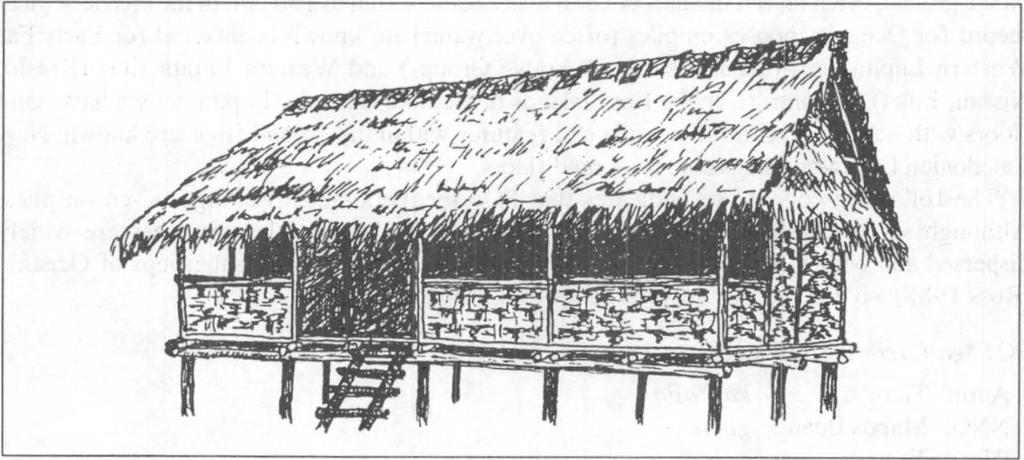

**Figure 3a:** POc *Rumaq ‘house’ POc *qatop ‘thatch, roof’, POc *kataman ‘doorway’, POc *tete ‘ladder or log bridge’, POc *gabʷari ‘area underneath house’

| **POc** |  | *kataman | ‘entrance to house, doorway’ |
| --- | --- | --- | --- |
| Adm | Mussau | *katamana* |  |
| NNG | Kove | *atama* |  |
| NNG | Yabem | *katam* |  |
| PT | Gumawana | *kaitamana* | ‘steps of house’ |
| PT | Dobu | *ʔataman* | ‘centre of a village’ |
| MM | Vitu | *ɣatama* | ‘doorpost’ |
| MM | Halia | *tamana* |  |
| SES | ’Are’are | *mana* | ‘hole, opening, outlet, doorway’ |
| NCV | Marino | *ɣatama* | ‘door’ |
| Mic | Woleaian | *gatama* |  |

*kataman probably referred to an entrance with its wooden framework. From ethnographic evidence we infer that true doors were not used: when entrances were to be closed they were probably blocked off by a barricade.

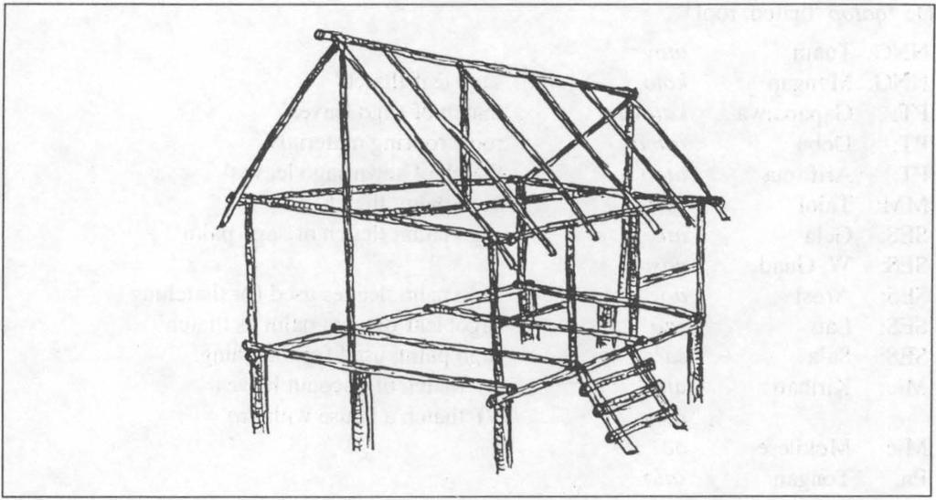

The following group of ten cognate sets indicate that early Austronesian dwelling houses were built with a robust and fairly heavy superstructure, including ridgepole, thatched roof, rafters and crossbeams. Those sets indicating POc *pupuŋ-an ‘ridgepole’ and POc *qatop ‘thatch, roof’ are consistent with ethnographic evidence indicating that gabled houses with a ridgepole supporting a thatched, probably two-section roof were built by both PMP and POc speakers.

| **PMP** |  | *bubuŋ | ‘ridgepole, ridge of the roof’ (Dempwolff 1938; Zorc 1994) |
| --- | --- | --- | --- |
| **PMP** |  | *buhuŋbuhuŋ | ‘ridgepole, ridge of the roof’ (Blust 1972b) |
| **POc** |  | *pupuŋ-an | ‘ridgepole’ (Blust 1983–84a) |
| Adm | Mussau | *puŋana* |  |
| NNG | Takia | *fuŋ, fuŋan* | ‘roof top’ |
| NNG | Numbami | *bomboaŋa* |  |
| PT | Misima | *ponan* |  |
| MM | Sursurunga | *puŋan* | ‘cover ridgepole with grass’ |
| MM | Halia | *puŋana* | ‘thatch’ |
| SES | Gela | *vuvuŋa* |  |
| SES | Arosi | *(abʷa)huŋa* | ‘the ridge of a house’ |
| SES | Arosi | *hunga-* | ‘roof top, centre-post of a round house’ |
| Mic | Carolinian | *ūŋ-wūŋ* | ‘large pole of traditional house’ |
| Pn | Tongan | *(toʔu)fufu* | ‘inner ridge-pole’ |
| Pn | East Futunan | *(taʔo)fufu* |  |
| Pn | Māori | *(tā)huhu* |  |
| Pn | Emae | *(tā)fufu* |  |

| **PMP** |  | *qatep | ‘thatch of sago palm leaves’ (Dutton 1994) ; ‘roof, thatch’ (ACD) |
| --- | --- | --- | --- |
| **POc** |  | *qatop | ‘thatch, roof’ |
| NNG | Tuam | *atov* |  |
| NNG | Mangap | *kōto* | ‘sago leaf thatch’ |
| PT | Gapapaiwa | *katova* | ‘thatch of sago leaves’ |
| PT | Dobu | *ʔatoa* | ‘roof, roofing materials’ |
| PT | Arifama | *atob* | ‘thatch of sewn sago leaves’ |
| MM | Taiof | *votof* | ‘sago palm; thatch’ |
| SES | Gela | *ato* | ‘sago palm; thatch of sago palm’ |
| SES | West Guadalcanal | *gaso* |  |
| SES | Arosi | *ao* | ‘sago palm, leaves used for thatching’ |
| SES | Lau | *sao* | ‘sago; leaf of sago palm as thatch’ |
| SES | Sa’a | *saʔo* | ‘sago palm, used for thatching’ |
| Mic | Kiribatese | *ato* | [N] ‘thatch of coconut leaves’ |
| Mic | Kiribatese | *ato-* | [V] ‘thatch a house with ato’ |
| Mic | Mokilese | *ɔc* |  |
| Pn | Tongan | *ʔato* |  |

Dutton (1994) has reviewed in detail cognate sets referring to sago palms (PMP *Rambia or *rumbia) and their uses. Ethnographic descriptions show that, where available, the leaves of sago palms (esp. *Metroxylon* spp.) are preferred by Austronesian speakers as roofing materials, several leaves being sewn together before being lashed to the ridge-pole and stringers. However, we suggest that ‘thatch of sago palm leaves’ is too narrow a gloss for PMP *qatep and POc *qatop. Leaves of other palms (e.g. coconut, nipa) and grass are also widely used as thatch. The more general gloss ‘thatch, roof’ allows for variation in roofing materials.

A second POc term for thatch is reconstructable, namely *rau(n), whose primary sense was ‘leaf, leaves, foliage’.

| **PMP** |  | *daSun | ‘leaf’ |
| --- | --- | --- | --- |
| **POc** |  | *rau(n) | ‘leaf; thatch’ |
| NNG | Poeng | *lau* | ‘leaf, paper; roof of grass’ |
| Mic | Kiribatese | *rau* | ‘thatch, made of pandanus leaves’ |
| Mic | Kiribatese | *rau-* | [V] ‘thatch s.t.’ |
| Fij | Bauan | *rau* | ‘dry grass or reeds for thatching houses’ |
| Pn | Samoan | *lau* | ‘leaf; thatch’ |
| Pn | Māori | *rau* | ‘thatch’ |

| **PMP** |  | *sasa(h,q) | ‘cut or collect palm leaves for roofing’ (Blust 1980b: 143) |
| --- | --- | --- | --- |
| **POc** |  | *saja(q) | ‘prepare thatching materials or begin to thatch a roof’ |
| SES | Gela | *sada* | ‘tie the thatch in beginning a roof’ |

| **PMP** |  | *kapit | ‘fasten thatch with battens or slats’ (Blust 1980b: 85) |
| --- | --- | --- | --- |
| **POc** |  | *kapit | ‘secure thatch with battens’ (generic sense: ‘grasp’; cf. Ch. 6, §2.7) |
| PT | Motu | *kahi* | ‘fix sticks to keep thatch or walls down’ |
| SES | Arosi | *ʔahi* | ‘put a broken limb into splints; splints’ |

| **PMP** |  | *kasaw | ‘rafter’ (Dempwolff 1938) |
| --- | --- | --- | --- |
| **POc** |  | *kaso | ‘rafter’ |
| PT | Gumawana | *kao* |  |
| MM | Bulu | *karo* |  |
| MM | Roviana | *gaso-* |  |
| SES | Gela | *gaho* |  |
| SES | Arosi | *ʔato* |  |
| NCV | Mota | *gaso* |  |
| Mic | Carolinian | *kat* | ‘stringers used to tie coconut shingles on to traditional houses’ |
| Fij | Bauan | *kaso* |  |
| Pn | Samoan | *ʔaso* |  |
| Pn | East Futunan | *kaso* |  |
| Pn | Nukuria | *gaso* | ‘roof thatch rafters’ |

Four POc terms can be reconstructed that referred either to posts or beams in a house.

| **PAn** |  | *SadiRi | ‘house post, pillar’ (ACD) |
| --- | --- | --- | --- |
| **POc** |  | *aRiRi | ‘post’ |
| NNG | Manam | *ariri* | ‘post’ |
| NNG | Numbami | *alili* | ‘house post, pillar’ |
| SES | Lau | *lili* | ‘sideposts; turn to one side’ |
| SES | Sa’a | *lili-* | ‘door posts’ |

There are some formal problems with the previous set. Some Oceanic forms show unexpected absence of initial *a-. Assimilation of the first consonant to the second apparently occurred in POc.

| **PMP** |  | *turus | ‘house post’ |
| --- | --- | --- | --- |
| **POc** |  | *turu(s) | ‘post’ |
| Adm | Mussau | *tutulu* | ‘house post’ |
| MM | Lihir | *tultul* | ‘doorpost’ |
| MM | Nehan | *tur* | ‘side posts’ |
| NCV | Mota | *tur, turi* | ‘trunk, body, hull’ |
| NCV | Mota | *tur(saŋa)* | ‘middle posts of a house, with fork on which the ridgepole (*saŋa*) sits’ |
| Mic | Carolinian | *ɨ̄r* | ‘main house post’ |
| Fij | Bauan | *duru* | ‘post, esp. the shorter posts of a house, on which the wall plates rest’ |

| **POc** |  | *bou | ‘(?) main bearers supporting raised floor or roof structure, or centre post supporting ridgepole’ |
| --- | --- | --- | --- |
| PT | Bwaidoga | *fou* | ‘main bearers of a house’ |
| PT | Misima | *popou* | ‘floor bearers, running from one end of house to the other’ |
| SES | Arosi | *boʔu* | ‘the crossbeam or stay in the roof to strengthen the house; sometimes the main-post in the centre rests on this; a cross’ (*boʔu* for expected *bou*) |
| SES | Kwaio | *bou* | ‘house post’ |
| Fij | Wayan | *bou* | ‘large posts in centre of a house, supporting the ridgepole’ |
| Fij | Bauan | *bou* | ‘main posts in a house’ |
| Pn | Samoan | *pou* | ‘house post, pillar’ |
| Pn | Samoan | *pou(tū)* | ‘main post’ |
| Pn | Samoan | *pou (lalo)* | ‘side post’ |
| Pn | Tongan | *pou* | ‘post, pillar’ |
| Pn | Tongan | *pou (lalahi)* | ‘big inner post (of house) on which joists rest’ |
| Pn | Tongan | *pou (fehihi)* | ‘small outer posts (of house)’ |

cf. also:

| SES | Arosi | *bou* | ‘seasoned dry wood’ |
| --- | --- | --- | --- |
| SES | Lau | *bou* | ‘seasoned log’ |
| SES | Gela | *bou* | ‘(timber) hard or seasoned’ |

The Papuan Tip (Bwaidoga, Misima) forms point to POc *pou, other forms to *bou. No non-Oceanic cognates of this set have been found. The precise meanings of PMP *Sadiri and *turus (and their POc reflexes) and of POc *bou are unclear. Reflexe of *turus most often refer to a main weight-bearing post, supporting either the top plates or ridge-pole. Reflexes of POc *bou, except in Central Pacific, usually refer to a main bearer supporting the raised floor or roof timbers.

The next term, POc *soka(r), evidently referred to any sort of bracing timber in a house or boat.

| **PMP** |  | *seŋkar | ‘cross-seat in boat, thwart’ (Blust 1972b: *soka) |
| --- | --- | --- | --- |
| **POc** |  | *soka(r) | ‘bracing timber, crossbeam’ (cf. Ch. 7, §2.5) |
| SES | ’Are’are | *oka* | ‘cross beam’ (irreg. for expected *toka) |
| Mic | Kiribatese | *oka* | ‘rafter of house going from horizontal beam to ridgepole’ |
| Fij | Bauan | *(i)ðoka* | ‘crossbeams in a house’ (*i-* < POc *i INS) |
| Fij | Bauan | *soka* | ‘smaller transversal beams in a house’ |
| Pn | Tongan | *hoka* | ‘king post in a Tongan house’ |
| Pn | Samoan | *soʔa* | ‘collar beam’ |
| Pn | West Futunan | *soka* | ‘some kind of bracing-timber in a house’ |

cf. also:

| NNG | Dami | *soko* | ‘roof’ |
| --- | --- | --- | --- |

### 3.5. Other structures associated with buildings

Under this heading we include terms for partitions, shelves, steps, and so on.

| **POc** |  | *logi | ‘partition, partitioned area’ |
| --- | --- | --- | --- |
| NNG | Hote | *lok* | ‘(garden) fence; wall of house’ |
| Mic | Kiribatese | *roki* | ‘screen (of mats +); curtain; bathroom; closed with screen’ (possibly borrowed from Polynesian) |
| Fij | Rotuman | *loki* | ‘the end of the interior of a house’ |
| Fij | Bauan | *logi* | ‘inner or private part of a house, used as a bedroom and for keeping valuables’ |
| Pn | Tongan | *loki* | ‘inner room’ |
| Pn | Samoan | *loʔi* | ‘inner room’ |
| Pn | Rapa | *roki* | ‘irrigated terrace’ |
| Pn | Tahitian | *roʔi* | ‘bed’ |
| Pn | Hawaiian | *loʔi* | ‘irrigated terrace for taro’ |
| Pn | Tuamotuan | *roki* | ‘wall of a temple; bed, couch’ |

cf. also:

| SES | Gela | *voki* | ‘room, partition in a house’ |
| --- | --- | --- | --- |

The meaning of *logi is not entirely clear. The weight of the ethnographic and linguistic evidence suggests that it probably referred to an inner room or partition containing a bed or sleeping platform screened off from the outer and more public area of a house. In contemporary societies the inner room is generally used as a bedroom for husband and wife and for storing valuables. However, it is conceivable that the POc term did have a more generalised meaning and could be applied to any partitioned area, whether house or garden (see also Ch. 5, § 12).

| **PMP** |  | *pa(n)tar | ‘shelf; bed-frame of wooden or bamboo laths’ (Blust 1980b: 123) |
| --- | --- | --- | --- |
| **POc** |  | *patar | ‘platform of any kind, including a bed frame of planks’ (see also Ch. 7, §3.1) |
| Adm | Seimat | *paca* | ‘canoe platform’ |
| Adm | Lou | *put-put* | ‘upper shelf’ |
| PT | Motu | *pata* | ‘shelf, table’ |
| PT | Molima | *vata-vata* | ‘platform of any kind’ |
| PT | Dobu | *pata-patara* | ‘platform’ |
| SES | Kwaio | *fā(laŋi)* | ‘raised plank floor or building with such a floor’ |
| SES | ’Are’are | *hā* | ‘generic name for stage, shelf or small platform above the fireplace, used as a depository’ |
| SES | Arosi | *hā* | ‘platform, for fishing, for storing yams, for laying out a corpse’ |
| NCV | Fortsenal | *vata* | ‘shelf, platform, rack’ |
| Fij | Bauan | *vata* | ‘shelf, loft, platform; bed in a corner of a native house’ |
| Pn | Tongan | *fata* | ‘loft or wide rack (for sleeping on, or for keeping food or other things on); stretcher, litter’ |
| Pn | Samoan | *fata* | ‘shelf, trestle, stretcher or litter’ |
| Pn | Tikopia | *fata* | ‘stage for storing food’ |

cf. also:

| Mic | Kiribatese | *pata* | ‘small house, hut, cabin, hovel’ |
| --- | --- | --- | --- |

| **PMP** |  | *pa(l,R)a | ‘shelf, rack’ |
| --- | --- | --- | --- |
| **POc** |  | *pa(r,R)a | ‘rack or shelf above hearth for storing or smoking food’ |
| Adm | Nauna | *pay* | ‘shelf above the hearth (for storing food, betel +, but not firewood)’ |
| Adm | Loniu | *pay* | ‘smoking rack for fish and storage rack above the hearth’ |
| NNG | Takia | *pira-par* | ‘storage platform above rafters’ |
| NNG | Gedaged | *fala* | ‘ceiling, sometimes used for storage’ |
| PT | Motu | *hara* | ‘platform of sticks on which meat is grilled’ |
| MM | Maringe | *fara* | ‘bamboo or wooden storage shelf, often located above a stone oven’ |
| SES | Lau | *fala* | ‘fishing stage, platform for drying nuts’ |
| NCV | Nguna | *vāla* | ‘bed, rack for storing yams or drying copra’ |
| Fij | Bauan | *vara* | ‘platform’ |

The Nauna, Loniu and Lau forms point to POc *paRa, the Fijian reflex to *para, while other Oceanic forms cited here are compatible with either reconstruction. [^6]

| **PMP** |  | *titey | ‘foot-bridge’ (Blust 1989) |
| --- | --- | --- | --- |
| **POc** |  | *tete | ‘single log bridge or ladder’; ‘climb a ladder, walk along a bridge or branch’ (Chowning 1991) |
| NNG | Kove | *tete* | ‘ladder; log leading into house’ |
| NNG | Manam | *tete* | ‘stairs, ladder’ |
| PT | Molima | *tete* | ‘walk along a ridge or branch of tree’ |
| PT | Molima | *(i)tete* | ‘bridge’ (*i-* < POc *i INS) |
| MM | Mono-Alu | *tete* | ‘ladder’ |
| SES | Bugotu | *tete* | ‘climb up on a fishing tripod’ |
| SES | Gela | *tete* | ‘cross a stream on a log or bridge; descend a ladder, not using hands’ |
| Mic | Carolinian | *(liga)tēte* | ‘ladder’ (*liga-* is prefix of uncertain origin) |
| Mic | Carolinian | *tēte* | ‘climb’ |

| **PMP** |  | *papan | ‘plank, board (of boat +)’ |
| --- | --- | --- | --- |
| **POc** |  | *baban | ‘board, plank; canoe strake’ (cf. Ch. 7, §2.4) |
| PT | Wedau | *papana* | ‘built-up canoe’ |
| SES | Lau | *baba* | ‘flat; long side board of canoe’ |
| SES | Arosi | *baba* | ‘slab, board’ |
| Fij | Wayan | *baba* | ‘board, plank, or other flat, wide piece of wood’ |
| Pn | Tongan | *papa* | ‘plank, board’ |
| Pn | Samoan | *papa* | ‘flat board, plank; rock’ |
| Pn | Māori | *papa* | ‘flat rock, slab, board’ |

| **PMP** |  | *pak(o,u) | ‘nail’ (Blust 1972b) |
| --- | --- | --- | --- |
| **PMP** |  | *paqet | ‘chisel’ (Dahl 1981) |
| **POc** |  | *pako | ‘wooden peg or pin’ |
| NNG | Mapos Buang | *pko* | ‘stake, peg; vertical stakes driven in to keep a log + in place’ |
| Fij | Bauan | *(i)vako* | ‘nail’ (*i-* < POc *i INS) |
| Pn | Samoan | *fao* | ‘nail’ |
| Pn | Tongan | *faʔo* | ‘nail’ |
| Pn | Tahitian | *fao* | ‘nail, chisel’ |

The Polynesian forms reflect PPn glottal stop rather than expected *k, a development found in several other words (Geraghty 1983, 1986).

As metal tools were almost certainly unknown to the early Austronesians, POc *pako and its PMP source presumably referred to wooden pegs or pins. In many languages the reflex of this term was later applied to iron nails. Terms for stone woodworking tools can be reconstructed for PAn and later interstages (see Ch. 4, §4.1), indicating a woodworking tradition continuing from PAn times.

### 3.6. Other structures associated with settlements

A general term for fireplace or hearth is reconstructable for PMP and continued in POc. We cannot tell from linguistic evidence whether or not fireplaces for cooking were built inside main dwelling houses.

| **PMP** |  | *dapuR | ‘hearth, fireplace’ (Dempwolff 1938) |
| --- | --- | --- | --- |
| **POc** |  | *rapu(R) | ‘hearth, fireplace; ashes’ |
| Adm | Nyindrou | *drahu (jih)* | ‘fireplace’ (*jih* ‘fire’) |
| PT | Motu | *rahu-rahu* | ‘fireplace, ashes’ |
| MM | Maringe | *(nak)rofu* | ‘ashes’ |
| SES | Gela | *ravu* | ‘ashes; side of a house where the fire is made (= *ravu ni mandiru*); site of a house (= *ravu ni vale*)’ |
| SES | Arosi | *rahu* | ‘ashes’ |
| NCV | Mota | *(ta)rowo* | ‘ashes; white ashes of burnt-out wood’ |
| Fij | Wayan | *ravu* | ‘ashes’ |
| Fij | Wayan | *(tā)ravu* | ‘fireplace’ |
| Fij | Bauan | *dravu* | ‘ashes’ |
| Pn | Samoan | *(magā)lafu* | ‘hearth’ |
| Pn | Tokelauan | *(gā)lafu* | ‘fireplace’ |
| Pn | Hawaiian | *lehu* | ‘ashes’ |

A term for an oven made with hot stones, POc *qumun is widely attested (see Ch. 6, §2.6, for further discussion).

| **POc** |  | *qumun | ‘oven made with hot stones; cook in a stone or earth oven’ (Chowning 1991; Lichtenberk 1994) |
| --- | --- | --- | --- |
| Adm | Seimat | *um* | ‘earth oven’ |
| NNG | Kairiru | *umu-i, um* | ‘cook in earth oven’ (singular/plural object) |
| PT | Molima | *ʔumula* | ‘stone oven’ |
| MM | Nalik | *umun* | ‘earth oven’ |
| MM | Nakanai | *humu* | ‘hearth; cook on the hearth by covering food with heated stones’ |
| SES | Gela | *umu* | ‘circular fireplace of stones’ |
| SES | ’Are’are | *ūmu* | ‘stone oven’ |
| SES | Arosi | *umu* | ‘round stone oven, with loose stones on top’ |
| NCV | Mota | *um* | ‘native oven’ |
| SV | Kwamera | *n-umun* | ‘earth oven’ |
| Mic | Kiribatese | *umun-* | ‘put s.t. to cook on hot stones in earth oven’ |
| Pn | Niuean | *umu* | ‘stone oven; food cooked in stone oven’ |
| Pn | Samoan | *umu* | ‘stone oven, consisting of a shallow cavity lined with stones on which a fire is lit and cleared away before the food is laid on the hot stones’ |
| Pn | Emae | *umu* | ‘earth oven’ |
| Pn | Māori | *umu* | ‘earth oven’ |

Two terms referring specifically to pits are reconstructable:

| **PMP** |  | *liaŋ | ‘hole, pit, cave’ |
| --- | --- | --- | --- |
| **POc** |  | *lua(ŋ) | ‘hole, pit, cave’ |
| Mic | Kiribatese | *rua* | ‘pit, ditch, trench’ |
| Pn | East Futunan | *lua* | ‘hole, pit, tomb, grave’ |
| Pn | Takuu | *rua* | ‘depression, hole in ground’ |
| Pn | Hawaiian | *lua* | ‘hole, pit’ |
| Pn | Tokelauan | *lua* | ‘big hole or pit’ |

| **POc** |  | *giRu, *guRi | ‘deep pit, (?) for grave or well’ |
| --- | --- | --- | --- |
| PT | Molima | *guli* | ‘grave; pit for pig hunting’ |
| PT | Motu | *guri* | ‘pit, grave’ |
| SES | Gela | *gilu* | ‘grave’ |
| SES | Lau | *kilu* | ‘hole, well’ |
| SES | Kwaio | *kilu* | ‘hole, pit’ |
| SES | Sa’a | *kilu* | ‘well, hole (in ground)’ |
| SES | Arosi | *giru* | ‘hole (in ground), grave’ |

The PT and SES forms in the above set are cognate on the assumption that metathesis occurred in one set or the other. In many Oceanic languages a reflex of *lua(ŋ) is the general term for any sort of hole, including pits used for cooking or for storing breadfruit and certain other crops. POc *giRu or *guRi may have referred to deep pits dug for graves or wells.

| **PMP** |  | *ba(l,r,R)a | ‘pen, enclosure for domestic animals’ (ACD) |
| --- | --- | --- | --- |
| **POc** |  | *baRa | ‘fence’ (ACD) |
| Adm | Mussau | *bala, bala-bala* | ‘fence’ |
| MM | Ramoaaina | *bala(da)* | ‘fence round a house’ |
| MM | Roviana | *bara* | ‘fence, wall; a fenced pen’ |
| SES | Lau | *bara* | ‘fence, enclosure, hedge’ |
| SES | Sa’a | *para* | ‘fence, enclosure’ |
| Fij | Wayan | *bā* | ‘fence or wall enclosing an area’ |
| Pn | Tongan | *pā* | ‘fence; wall; enclosure, fish trap’ |
| Pn | Tokelauan | *pā* | ‘fence, wall, seawall and reclaimed land behind it’ |
| Pn | Rarotongan | *pā* | ‘fish weir with stone walls’ |
| Pn | Māori | *pā* | ‘stockade, fortified place; fish weir’ |
| Pn | Māori | *pā-ia* | ‘block up, act as barrier’ |

| **POc** |  | *bayat | ‘fence, boundary marker’ |
| --- | --- | --- | --- |
| **POc** |  | *bayat-i | ‘make a garden boundary’ |
| PT | Gumawana | *bayata* | ‘garden boundary made by terracing rocks’ |
| PT | Gumawana | *bayasi* | ‘make a garden boundary’ |
| PT | Iduna | *bai* | ‘stick used as garden boundary; roof baton’ |
| MM | Tolai | *bait* | ‘enclose with a fence’ |
| MM | Tolai | *ba-bait* | ‘fence’ |
| SES | Arosi | *bai-bai* | ‘large logs put round a finished garden’ |
| NCV | Mae | *pae* | ‘fence, wall’ |
| Fij | Bauan | *bai* | ‘fence round garden or town’ |
| Pn | Tuvalu | *pae* | ‘stones round an earth oven’ |
| Pn | Tikopia | *pae* | ‘wall-like accumulation of stones’ |
| Pn | West Futunan | *bae* | ‘a stone fence’ |

| **PAn** |  | *qa(l,R)ad | ‘fence, palisade’ (Ross 1994a: 459) [^7] |
| --- | --- | --- | --- |
| **POc** |  | *qaRa(r) | ‘fence’ |
| NNG | Numbami | *ala* | ‘fence (e.g. garden fence)’ |
| NNG | Kove | *ala* |  |
| PT | Bwaidoga | *ala* |  |
| PT | Motu | *ara* | ‘fence of upright stakes’ |
| NCV | Raga | *ara* |  |
| NCV | Nguna | *na-ara* | ‘wall of bamboo or cane’ |
| Pn | Tongan | *ʔā* | ‘fence, wall, enclosure’ |
| Pn | East Uvean | *ʔā* | ‘palisade’ |

One further reconstruction, POc *kaRi ‘garden fence or partition’, is given with supporting evidence in Chapter 5, § 6.

Also included here is a reconstruction for a path.

| **PMP** |  | *zalan | ‘path, road’ (Dahl 1976) |
| --- | --- | --- | --- |
| **POc** |  | *jalan | ‘path’ |
| Adm | Nauna | *cal* |  |
| Adm | Drehet | *saŋ* | ‘trail, path, road’ |
| NNG | Mangap | *zala* |  |
| NNG | Manam | *zala* | ‘path, road, door’ |
| PT | Motu | *dala* |  |
| MM | Bali | *dalaŋa* |  |
| MM | Tigak | *salan* |  |
| MM | Tinputz | *hanan* |  |
| MM | Banoni | *sanana* |  |
| SES | Tolo | *salana* | ‘road, path, way’ |
| SES | Sa’a | *tala* | ‘path, road, way’ |
| NCV | Mota | *sala* |  |
| Mic | Mokilese | *al* |  |
| Mic | Woleaian | *yala* | ‘road, way, path’ |
| Fij | Rotuman | *sala* |  |
| Fij | Wayan | *ðala* | ‘animal track’ (*ðaa-levu* ‘path’) |
| Fij | Bauan | *sala* | ‘path, road, track’ |
| Pn | Tongan | *hala* |  |
| Pn | Māori | *ara* |  |

### 3.7. Settlement patterns

Some contemporary Oceanic societies live in villages of up to several hundred people in size; others live in scattered hamlets or homesteads containing one or two extended families. No POc term specifically meaning ‘village’ or ‘nucleated settlement’ can be reconstructed with any confidence. It appears that present-day terms denoting ‘village’ or some sort of nucleated settlement originally meant something else. This point is illustrated by the following four cognate sets.

| **PMP** |  | *banua | ‘inhabited territory, where a community’s gardens, houses and other possessions are’ (Blust 1987) |
| --- | --- | --- | --- |
| **POc** |  | *panua | (1) ‘inhabited area or territory’; (2) ‘community together with its land and things on it’; (3) ‘land, not sea’; (4) ‘(with reference to weather) the visible world, land and sky’ |
| Adm | Mussau | *anua* | ‘land’ |
| Adm | Penchal | *panu* | ‘village’ |
| NNG | Gedaged | *panu* | ‘village, settlement, hamlet’ |
| NNG | Manam | *anua* | ‘village’ |
| NNG | Manam | *anua izara* | ‘dawn’ (*anua idaradara* ‘evening glow’) |
| NNG | Tami | *panu* | ‘house’ |
| PT | Motu | *hanua* | ‘village, town’ |
| PT | Motu | *hanua(boi)* | ‘night’ (*boi* < POc *boŋi ‘night’) |
| PT | Molima | *vanua* | ‘house’ |
| MM | Vitu | *vanua* | ‘garden’ |
| MM | Tabar | *vanua* | ‘house’ |
| MM | Taiof | *fan* | ‘village’ |
| SES | Bugotu | *vanua* | ‘land, island’ |
| SES | Lau | *fanua* | ‘land, the earth, world; weather’ |
| SES | Ulawa | *hanua* | ‘land, country, village place, country; the area where a person lives, where his possessions are’ |
| NCV | Mota | *vanua* | ‘land, island, village, place’ |
| Mic | Woleaian | *faliu* | ‘land, island’ |
| Fij | Rotuman | *hanua* | ‘land, country, place; native land or place, home’ |
| Fij | Bauan | *vanua* | ‘land (not sea), territory, region, place, community, country; (in expressions for weather) the visible world, land, sea and sky’ |
| Pn | Tongan | *fonua* | ‘land, country, territory, place; people (of the land)’ |
| Pn | Hawaiian | *honua* | ‘land, earth’ |

Although reflexes of PMP *banua carry the meaning ‘village’ in a number of languages belonging to different high-order subgroups (or at least are given this gloss in the dictionaries) a host of other evidence, summarised in Blust (1987: 94-95, 99-100) suggests that PMP *banua and its reflex in POc referred primarily to an inhabited territory; not only to the land but to the human population and dwellings and all plant and animal life and other elements that contribute to the maintenance of the human community—a complex concept with no simple equivalent in European languages (but compare the many senses of ‘land’ and ‘country’). Indeed, the single word glosses that bilingual dictionaries give for reflexes of *banua should generally be regarded not as accurate descriptions of their meaning in the source language, but as shorthand translations designed to fit the categories of the target language.

| **POc** |  | *pera | ‘(?) settlement, open space associated with a house or settlement’ |
| --- | --- | --- | --- |
| NNG | Manam | *pera* | ‘house’ |
| SES | Bugotu | *vera* | ‘courtyard, open space in a village’ |
| SES | Tolo | *vera(na)* | ‘village, home, country, place where one lives’ |
| SES | Lau | *fera* | ‘land; village; habitation, home, artificial island (built for habitation)’ |
| SES | Lau | *(ma)fera* | ‘hamlet, of two or more houses’ |
| SES | Baegu | *fera* | ‘hamlet, a named locality’ |
| SES | Kwaio | *fela* | ‘skull house’ |
| SES | ’Are’are | *herā* | ‘an agglomeration of houses, a village’ |
| SES | ’Are’are | *he-hera* | ‘an open place in front of the houses for people to walk’ |
| SES | Sa’a | *hera* | ‘courtyard’ |
| SES | Arosi | *hera* | ‘open space for dancing, usually to the east of chief’s burial ground; burial space, usually enclosed by stone’ |

cf. also:

| NCV | Mota | *varea* | ‘village, place of a village settlement’ |
| --- | --- | --- | --- |
| NCV | Raga | *a-vare* | ‘outside the house’ |
| NCV | Nguna | *varea* | ‘men’s house’ |

The term *pera is well-attested in both major subgroups of Southeast Solomonic (i.e. Cristobal-Malaitan and Guadalcanal-Gelic) but has only one secure external cognate, in Manam. The range of meanings or glosses associated with this cognate set makes it impossible to make a firm semantic reconstruction either for POc or for PSES. Our best guess is that *pera referred to some sort of settlement or space associated with this.

For POc *malaqai, Milke (1968) proposed the gloss ‘village’. However, that gloss applies only to its few Western Oceanic reflexes. PPn *malaʔe clearly denoted an open space in the centre of a settlement, used for communal activities.

| **POc** |  | *m(a,e)laqai | ‘(?) open space in a settlement’ |
| --- | --- | --- | --- |
| NNG | Yabem | *melaʔ* | ‘village’ |
| PT | Wedau | *melagai* | ‘village’ |
| **PPn** |  | *malaqe | ‘open, cleared space used as meeting place or ceremonial place’ (Biggs 1993) |
| Pn | Tongan | *malaʔe* | ‘village green, park, playground, open market place’ |
| Pn | Samoan | *malae* | ‘open space in the middle of a village, meeting-ground’ |
| Pn | Māori | *marae* | ‘enclosed space before house, courtyard’ |

Rotuman *maraʔe* ‘open space in centre of village’ is indicated to be a loan from Polynesian by the presence of *r* and glottal stop for expected *l* and zero. Kiribati *marae* ‘empty space, clear place, public place, sports ground’ is probably borrowed from Polynesian.

Another POc term whose reflexes in a few daughter languages now mean ‘village’ is *mʷalala. Once again, however, the balance of the evidence suggests that it did not have this meaning in POc.

| **POc** |  | *mʷalala | ‘cleared land, land free of encumbrances, i.e. cleared of vegetation but not built on or planted’ |
| --- | --- | --- | --- |
| Adm | Drehet | *mʷalaŋ* | ‘open area/clearing’ |
| NNG | Manam | *malala* | ‘market place, assembly place’ |
| PT | Bwaidoga | *melala* | ‘village’ |
| MM | Vitu | *malala* | ‘village’ |
| MM | Nakanai | *malala* | ‘a garden, cleared but not planted; village plaza’ |
| MM | Tabar | *marar* | ‘cleared ground’ |
| NCV | Nguna | *mʷalala* | ‘dancing place’ |
| NCal | Nengone | *(gu)marara* | ‘cleared ground’ (*gu-* ‘piece’) |
| Fij | Wayan | *ŋʷalala* | ‘(esp. land) unoccupied, vacant, not in use; (trees, buildings) widely spaced; (person) free, at liberty’ |
| Fij | Bauan | *ŋalala* | ‘free from encumbrances, at liberty’ |

cf. also:

| NCV | Lonwolwol | *har* | ‘dancing place, ceremonial clearing in village’ |
| --- | --- | --- | --- |
| Fij | Bauan | *lala* | ‘(esp. land) empty, unoccupied, uninhabited’ |
| Pn | Tongan | *lala* | ‘(place) uninhabited, empty or almost so’ |

Various POc terms for garden land and for land not under cultivation can be reconstructed (see Ch. 5, §3). Here we cite only one, POc *qutan ‘bushland, hinterland, away from village and gardens close to village’ which goes back to PAn *quCan ‘fallow land’ (Blust 1989); ‘scrubland, bush’ (ACD).

## 4. On variation and change in early Oceanic architectural styles and settlement patterns

Contact with Papuan (non-Austronesian) speaking communities may have led to local variation and change in the architectural forms and settlement patterns of Proto Oceanic speakers or their immediate descendants. Earlier we touched on the possibility that the concept of a ‘men’s clubhouse’, associated with POc *kamali(R), was borrowed from Papuan speakers. The same applies to the concept of an oven made with heated stones, POc *qumun (Chowning 1991, Lichtenberk 1994). Such ovens appear to have a much greater antiquity in Near Oceania and Australia than in Southeast Asia (Allen, Gosden & White 1989: 550-551; Berbetti & Allen 1972, Horton 1994).[^8]

In interstages postdating the break-up of POc a number of changes can be discerned in terms for houses and their parts. For example, POc *bou probably meant ‘main bearer or cross beam’, but its Fijian reflexes now mean ‘the tall or centre posts of a house’ while in PPn this term became the generic name for ‘post’, while POc *turu(s) ‘(main) post’ was lost. The POc word for ‘entrance, doorway’, *katama, is replaced in PPn by *faʔitoka. In Central Pacific, or at least in the eastern region of the Central Pacific dialect chain (ancestral to Polynesian and some Eastern Fijian dialects), *pale replaced *Rumaq as the ordinary term for a dwelling house. Further study is needed to see whether any of these linguistic changes can be correlated with transformations in house forms in the eastern Fiji-Polynesian area.

## 5. Conclusion

Where comparable evidence is available, the testimonies of archaeology, ethnology and comparative linguistics are generally consistent regarding the architecture and settlement patterns of the Austronesian speakers who colonised the SW Pacific in the late 2nd millennium BC. Various POc terms for types of buildings and parts of a dwelling house and for associated artefacts and activities have been reconstructed, including some elements that can be associated with Austronesian as opposed to non-Austronesian speaking societies. The more completely excavated Lapita sites show some of these elements and nothing inconsistent. At least some dwellings in Far Western Lapita sites were of the raised platform type. However, as one moves east into the Solomons and beyond, they more often sat on the ground, as is still the case ethnographically. It should perhaps be emphasised that the equation of Lapita sites with Austronesian languages does not rest solely on the evidence concerning house forms and settlements. This equation is supported by a wide range of correspondences in many cultural domains of which we have canvassed only one in detail. It is also in keeping with the geographic distribution of these languages and sites. In our view the conjunction of the two data sets opens up possibilities that are well worth exploring further. When both are employed they allow the construction of a far more rounded picture of a period of considerable foment in Pacific colonisation than either does alone.

## Notes

[^1]: This chapter is based on a longer paper by Green and Pawley (in press, vol. 3) which correlates archaeological findings from Lapita sites with the linguistic work presented here. The current version includes some minor revisions and the archaeological data are omitted here, as the aim of the present series is to reconstruct POc lexicon without attempting to treat archaeological evidence in any detail. We are indebted to Meredith Osmond for research assistance and comments. Peter Sheppard, Richard Walter, Janet Davidson, Patrick Kirch, Malcolm Ross and Valerie Green also read the draft and suggested a number of improvements.
[^2]: Blust (1976b) points out ways in which archaeological and linguistic evidence can be complementary, corroboratory or contradictory.
[^3]: The nature of the contrast between the historical methods of comparative ethnology and linguistics is discussed in Blust (1980a), Green (1994a) and Pawley and Ross (1993, 1995).
[^4]: It has been suggested that the expansion of many of the world’s large, well-defined language groups was associated with the spread of agriculture (Bellwood 1991, Renfrew 1987, 1992). Be that as it may, reconstruction of fairly remote protolanguages is certainly easiest when the number of descendants is large, as is the case with such well-known families as Indo-European (at least 140 languages) and Austronesian (about 1,000 languages). The conservativeness of a good many Austronesian languages is such that, if they were to change no more over the next 5,000 years than they have in the past 5,000 or so, their genetic relatedness would still be obvious, some 10,000 years after their divergence.
[^5]: For example, Green (1966, 1967, 1979, 1981, 1986, 1994a, 1994b); Kirch and Green (1987); Pawley (1981, 1982a, 1996a); Pawley and R.Green (1973, 1984); Pawley and K.Green (1971); Pawley and Pawley (1994); Pawley and Ross (1993). We have not been alone in this enterprise. From the 1920s on, Kenneth Emory was a pioneer in Polynesian culture history, when archaeological and historical linguistic studies in that region were in their infancy and the main reliance was on comparative ethnology. For more recent interdisciplinary work see Bellwood (1978, 1985, 1987, 1991); Blust (1976b, 1980a, 1984-85, 1994); Chowning (1991); French-Wright (1983); Kirch (1984); Osmond (1996); Ross (1989a); Shutler and Marek (1975); Walter (1989); and various papers in Pawley and Ross eds (1994).
[^6]: Blust (ACD) has proposed POc *pala or *paRa ‘platform, firewood shelf above the hearth’ and, under the entry headed Western Malayo-Polynesian *palapala ‘scaffolding’, also refers to PMP *paRa ‘storage shelf’.
[^7]: Reconstruction of PMP *-R- is based on Manobo (S. Philippines) data: Tigwa Manobo, Binukid, Kinamigin, Sarangani Manobo, Western Bukidnon Manobo, Ilianen Manobo *ʔalad*; Obo, Dibabawon *ʔaad*; Tagabawa *alad* (Elkins 1974:607).
[^8]: Note that although ovens are very ancient in Australia, stones do not appear to have been used in them.